# Regression and Bootstrapping

Juan Carlos Castro

10/21/2018

### Question 1

##### Data-generating equation

```r
set.seed(7)
#data 100 observations
X <- seq(1,5,length.out = 100)
errors <- rnorm(100)
Y <- 3*X + errors

#outlier
X[100] = 20
Y[100] = -20

#models
reg_no_outlier <- lm(Y[1:99] ~ X[1:99])
reg_outlier <- lm(Y ~ X)
```

##### Regression results without outlier

```r
summary(reg_no_outlier)
```

```
##
## Call:
## lm(formula = Y[1:99] ~ X[1:99])
##
## Residuals:
##     Min      1Q  Median      3Q     Max
## -1.7187 -0.6272 -0.0104  0.6235  2.4417
##
## Coefficients:
##             Estimate Std. Error t value Pr(>|t|)
## (Intercept)  0.53659    0.26586   2.018   0.0463 *
## X[1:99]      2.86745    0.08319  34.467   <2e-16 ***
## ---
## Signif. codes:  0 '***' 0.001 '**' 0.01 '*' 0.05 '.' 0.1 ' ' 1
##
## Residual standard error: 0.9558 on 97 degrees of freedom
## Multiple R-squared:  0.9245, Adjusted R-squared:  0.9237
## F-statistic:  1188 on 1 and 97 DF,  p-value: < 2.2e-16
```

##### Regression results with outlier

```r
summary(reg_outlier)
```

```
##
## Call:
## lm(formula = Y ~ X)
##
## Residuals:
##      Min       1Q   Median       3Q      Max
## -24.3019  -2.6673   0.2474   3.3121   7.4247
##
## Coefficients:
##             Estimate Std. Error t value Pr(>|t|)
## (Intercept)   9.6293     0.8254  11.667   <2e-16 ***
## X            -0.2664     0.2197  -1.212    0.228
## ---
## Signif. codes:  0 '***' 0.001 '**' 0.01 '*' 0.05 '.' 0.1 ' ' 1
##
## Residual standard error: 4.496 on 98 degrees of freedom
## Multiple R-squared:  0.01477,    Adjusted R-squared:  0.004722
## F-statistic:  1.47 on 1 and 98 DF,  p-value: 0.2283
```

##### Data visualization

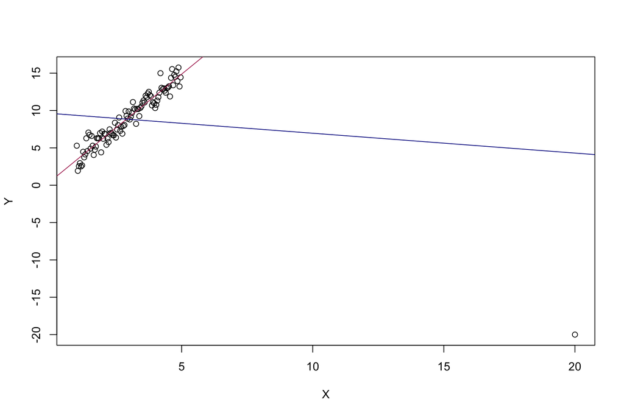

Figure 1. Scatterplot of 100 Y values dependent on the single variable X with coefficient 3 and a normal error term. The 100th observation was modified to simulate the effect of an outlier in a univariate regression model. The red line is the regression fitted to the first 99 observations, and the blue line is fitted to the 100 observations.

### Question 2

A function `Predict_Intervals` was created to solve this problem, and can be reused for different scenarios. The function takes the predictor matrix, the simulated parameters of a linear model, and the desired number of simulations and returns the confidence intervals for each of the rows in the predictor matrix

```r
Predict_Intervals <- function(xmatrix,sim_params,num_sims) {
  sim_ys <- data.frame()
  for (j in 1:length(xmatrix[,1])) {
    for (i in 1:num_sims) {
      terms <- c(sim_params@coef[i,1])
      for (k in 1:length(xmatrix[j,])) {terms[1+k] = sim_params@coef[i,1+k]*xmatrix[j,k]}
      sim_ys[i,j] <- sum(terms) + rnorm(1, 0, sim_params@sigma[i])
    }
  }
  return (apply(sim_ys,2,quantile,probs = c(0.025, 0.975)))
}
```

Loading the data, isolating control group, creating the linear model, and simulating the parameters (betas and sigmas)

```r
#loading packages and data
library(arm)
library(Matching)
data("lalonde")

#isolating control group
lalonde_control <- lalonde[which(lalonde$treat == 0),]

#linear model
predict_re78_control <- lm(re78 ~ age + educ + re74 + re75 + educ*re74 +
                     educ*re75 + age*re74 + age*re75 + re74*re75, data = lalonde_control)

#simulating the parameters
sim_params_re78 <- sim(predict_re78_control, n.sims=10000)
```

Scenario (a)

```r
#age domain
ages <- c(min(lalonde_control$age):max(lalonde_control$age))
length(ages)
```

```
## [1] 39
```

```r
#calculating the medians
med_educ <- median(lalonde_control$educ)
med_re74 <- median(lalonde_control$re74)
med_re75 <- median(lalonde_control$re75)

#creating the predictor matrix for scenario a
matrix_a <- as.data.frame(cbind(ages, rep(med_educ,39), rep(med_re74,39), rep(med_re75,39)))
names(matrix_a) = c('age','educ','re74','re75')
matrix_a['educ*re74'] <- matrix_a$educ*matrix_a$re74
matrix_a['educ*re75'] <- matrix_a$educ*matrix_a$re75
matrix_a['age*re74'] <- matrix_a$age*matrix_a$re74
matrix_a['age*re75'] <- matrix_a$age*matrix_a$re75
matrix_a['re74*re75'] <- matrix_a$re74*matrix_a$re75
```

##### Prediction intervals for scenario (a)

```r
#95% prediction intervals for scenario a
pred_intervals_a <- Predict_Intervals(matrix_a, sim_params_re78, 1000)
pred_intervals_a
```

```
##              V1        V2        V3        V4        V5        V6
## 2.5%  -7177.923 -6193.672 -6749.689 -6420.237 -6209.029 -7243.199
## 97.5% 15981.066 15077.525 15162.231 14784.012 15173.119 14799.877
##              V7        V8        V9       V10      V11       V12       V13
## 2.5%  -5761.893 -5778.435 -7015.342 -6935.274 -6274.84 -6898.587 -6580.781
## 97.5% 14913.745 14838.304 15846.300 14663.497 15631.93 14927.390 14756.742
##             V14       V15       V16       V17       V18       V19
## 2.5%  -4956.587 -7115.736 -6480.174 -6960.877 -6386.888 -6658.832
## 97.5% 15899.997 15657.338 15237.732 15044.102 15062.949 14414.476
##             V20       V21       V22       V23       V24       V25      V26
## 2.5%  -6008.585 -6406.569 -7623.332 -6630.512 -6613.343 -7161.153 -7051.05
## 97.5% 15241.729 15072.794 14987.782 14714.511 14328.548 14747.250 15888.07
##             V27       V28       V29      V30       V31       V32      V33
## 2.5%  -7331.795 -8298.713 -7704.808 -6636.27 -7226.796 -6706.213 -6919.70
## 97.5% 14356.370 15706.502 15107.595 15613.09 15995.125 15370.296 15151.07
##            V34       V35       V36       V37       V38       V39
## 2.5%  -7582.14 -6706.749 -6851.913 -6830.341 -5429.808 -7613.736
## 97.5% 15141.95 15937.937 15935.779 15349.188 15290.492 15235.871
```

##### Visualization

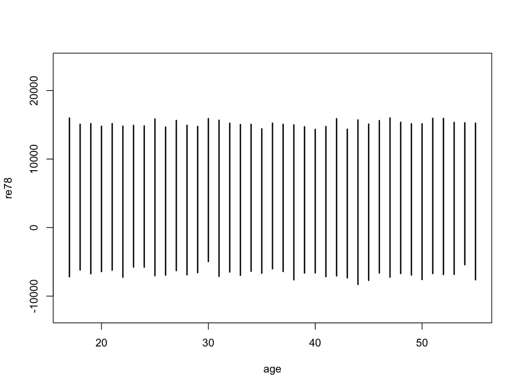

Figure 2. Confidence intervals for re78 predicted for each age in the control group of the lalonde data set. The linear model used age, educ, re74, and re75 as predictors, including some term interactions, and holding educ, re74, and re75 at their medians

Scenario (b)

```r
#calculating the 90% quantiles
quant90_educ <- quantile(lalonde_control$educ, probs = 0.9)
quant90_re74 <- quantile(lalonde_control$re74, probs = 0.9)
quant90_re75 <- quantile(lalonde_control$re75, probs = 0.9)

#creating the predictor maxtrix for scenario b
matrix_b <- as.data.frame(cbind(ages, rep(quant90_educ,39), rep(quant90_re74,39), rep(quant90_re75,39)))
names(matrix_b) = c('age','educ','re74','re75')
matrix_b['educ*re74'] <- matrix_b$educ*matrix_b$re74
matrix_b['educ*re75'] <- matrix_b$educ*matrix_b$re75
matrix_b['age*re74'] <- matrix_b$age*matrix_b$re74
matrix_b['age*re75'] <- matrix_b$age*matrix_b$re75
matrix_b['re74*re75'] <- matrix_b$re74*matrix_b$re75
```

##### Prediction intervals for scenario (b)

```r
#95% prediction intervals for scenario b
pred_intervals_b <- Predict_Intervals(matrix_b, sim_params_re78, 1000)
pred_intervals_b
```

```
##              V1        V2        V3        V4        V5        V6       V7
## 2.5%  -4912.109 -4677.855 -4706.432 -4852.436 -5609.819 -5705.162 -4614.79
## 97.5% 17260.011 16362.365 16611.408 17515.136 17258.101 17374.352 16930.81
##             V8        V9       V10       V11       V12       V13       V14
## 2.5%  -5241.35 -5608.413 -5117.301 -4201.591 -3886.918 -5379.585 -5474.035
## 97.5% 17143.98 16350.974 16414.451 16370.781 17013.846 17040.528 17355.421
##            V15       V16       V17       V18       V19       V20       V21
## 2.5%  -5264.91 -4071.231 -5600.649 -5796.925 -4988.405 -5221.821 -5693.779
## 97.5% 16738.48 17478.223 16927.463 17478.175 16630.090 17404.680 17517.563
##             V22       V23       V24      V25       V26      V27       V28
## 2.5%  -4948.037 -5046.305 -4570.332 -5104.03 -4562.489 -5031.28 -5634.974
## 97.5% 17746.705 17515.771 16930.689 17095.42 17619.269 17693.04 18662.230
##            V29       V30       V31       V32       V33       V34       V35
## 2.5%  -5973.23 -5866.462 -5716.726 -6238.022 -4979.857 -5312.923 -6013.244
## 97.5% 17205.93 18337.480 16904.452 17657.612 18273.095 18080.619 18148.606
##             V36       V37       V38       V39
## 2.5%  -6082.751 -5760.295 -5888.925 -5834.698
## 97.5% 18189.384 17706.880 18350.799 18529.227
```

##### Plot for (b)

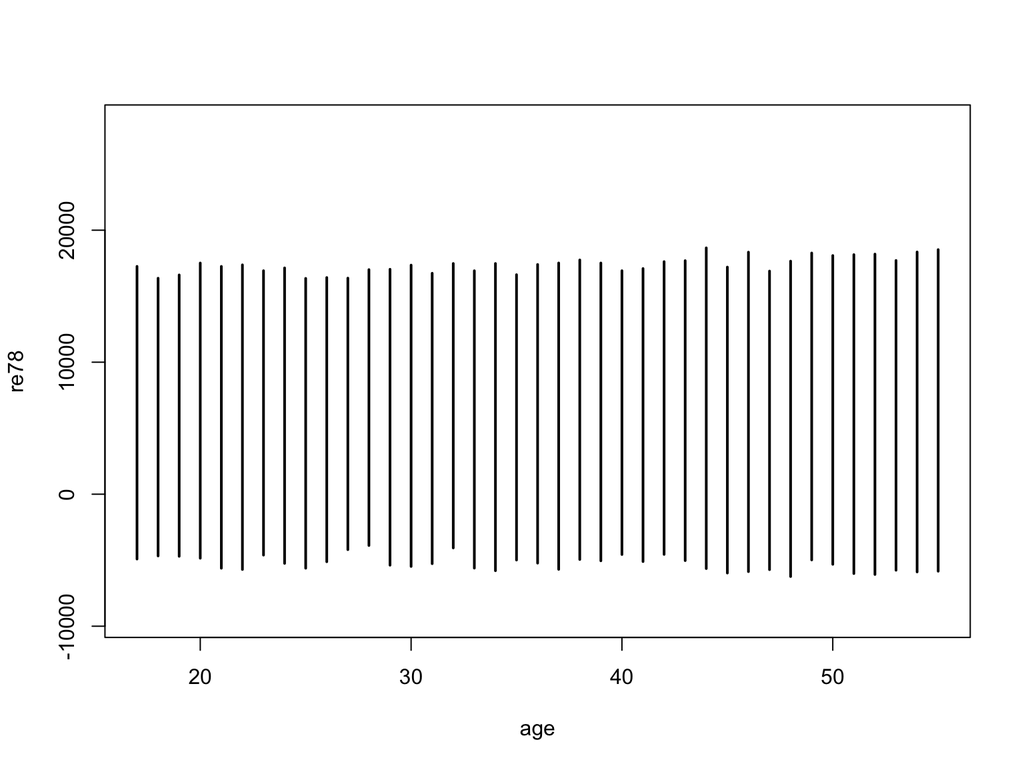

Figure 3. Confidence intervals for re78 predicted for each age in the control group of the lalonde data set. The linear model used age, educ, re74, and re75 as predictors, including some term interactions, and holding educ, re74, and re75 at their 90% quantiles

### Question 3

```r
set.seed(3)
#loading data and packages
library(foreign)
nswdata <- read.dta('/Users/juan/Downloads/nsw.dta')

#my bootstrap function. The obs parameter is a matrix in which the observations are each of the rows. B is the number of samples set as n by default

my_bootstrap <- function(obs, B = nrow(obs)) {
  boot_estimates <- data.frame(cbind(intercept = c(NA),treat = c(NA)))
  for (i in 1:B) {
    inds_samp <- sample(1:nrow(obs), nrow(obs), replace = TRUE)
    one_boot_data <- obs[inds_samp,]
    boot_estimates[i,] <- lm(re78 ~ treat, data = one_boot_data)$coef
  }
  return(boot_estimates)
}

#bootstrapped estimates
nsw_bootstrapped <- my_bootstrap(nswdata)
#bootstrapped 95% confidence interval
bootstrap_intervals <- apply(nsw_bootstrapped, 2, quantile, probs = c(0.025, 0.975))
#analytical 95% confidence interval
analytical_interval <- confint(lm(re78 ~ treat, data = nswdata))
```

##### Bootrstrapped 95% confidence interval

```r
t(bootstrap_intervals)
```

```
##                 2.5%    97.5%
## intercept 4560.99557 5642.290
## treat      -67.24301 1826.428
```

##### Analytical 95% confidence interval

```r
analytical_interval
```

```
##                2.5 %   97.5 %
## intercept 4495.60595 5684.491
## treat      -40.52635 1813.134
```

##### Comparison of the treatment coefficient between the bootrstrap and the analytical models

```r
rbind(bootstrap = bootstrap_intervals[,2], analytical = analytical_interval[2,])
```

```
##                 2.5%    97.5%
## bootstrap  -67.24301 1826.428
## analytical -40.52635 1813.134
```

##### Data visualization

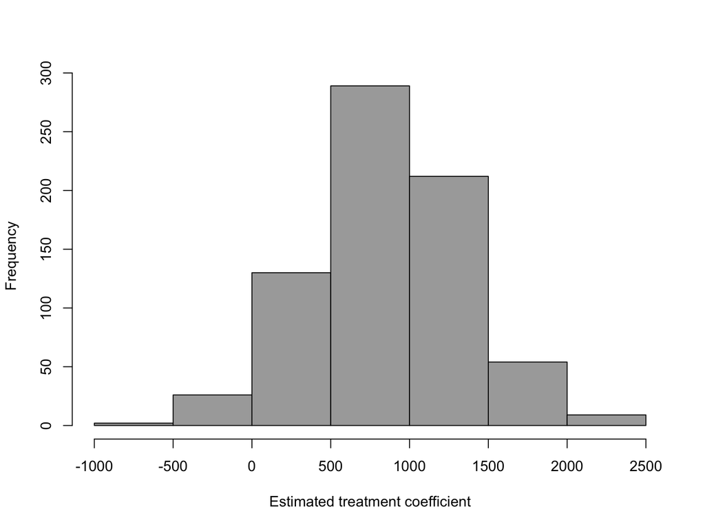

Figure 4. Histogram that shows the distribution of the bootstrapped treatment coefficient from the nsw data

We can see how the bootstratp technique provided us with approximations close to the real confidence intervals (which are also estimates and there’s uncertainty to them), demonstrating the power of bootstrapping. In the next question we will use another metric to evaluate the bootstrap performance.

### Question 4

Function R_squared

```r
R_squared <- function (pred_ys, real_ys) {
  SSE = sum((pred_ys-real_ys)^2)
  SST = sum((real_ys-mean(real_ys))^2)
  return(1-SSE/SST)
}
```

Example using the model from question 3

```r
#predicted re78 by treatment
linmod <- lm(re78 ~ treat, data = nswdata)
pred_ys_re78 <- predict(linmod)

#predicted re78 by treatment using the means of the bootstrapped coefficients calculated in (3)
intercept_boot <- mean(nsw_bootstrapped$intercept)
treat_boot <- mean(nsw_bootstrapped$treat)
pred_ys_re78_bootstrap <- nswdata$treat*treat_boot + intercept_boot
```

R squared of the original linear regression

```r
R_squared(pred_ys_re78, nswdata$re78)
```

```
## [1] 0.004871571
```

R squared using the means of the bootstrapped coefficients

```r
R_squared(pred_ys_re78_bootstrap, nswdata$re78)
```

```
## [1] 0.00486819
```

R squared extracted from the linear model showing the function works

```r
summary(linmod)$r.squared
```

```
## [1] 0.004871571
```

We can see that the model using the means of the bootstrapped coefficients performs very similar to the original linear model when tested using the R squared value

### Question 5

```r
#logistic regression model
logit_nsw <- glm(treat ~ age + education + black + hispanic + married + nodegree + re75, family = "binomial", data = nswdata)

#estimated probabilities
estimated_probs <- predict(logit_nsw, type = "response")
estimated_probs_df <- data.frame(nswdata$treat,estimated_probs)

#getting indexes that will allow separation between treatment and control group
treat_inds <- which(estimated_probs_df$nswdata.treat == 1)
```

##### Visualizations

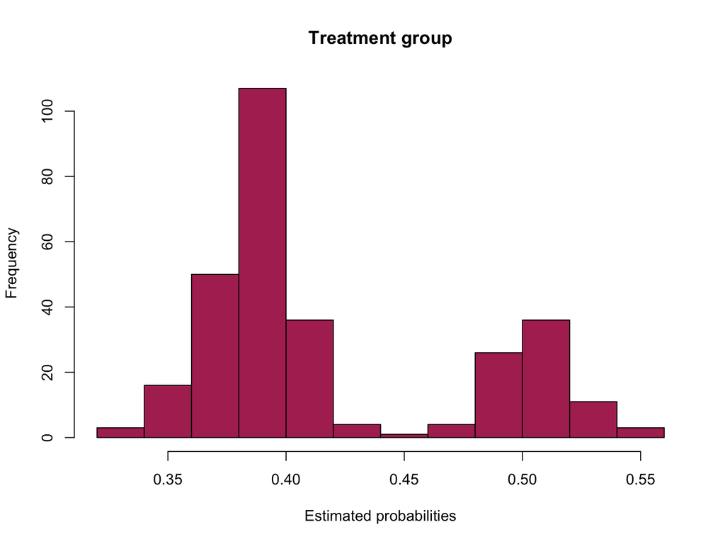

Figure 5. Histogram that shows the distribution of the treatment group’s estimated probabilities of being predicted as part of the treatment group. The probabilities are estimated by a logistic regression model using every parameter as predictor exlcuding re78 and no interaction terms

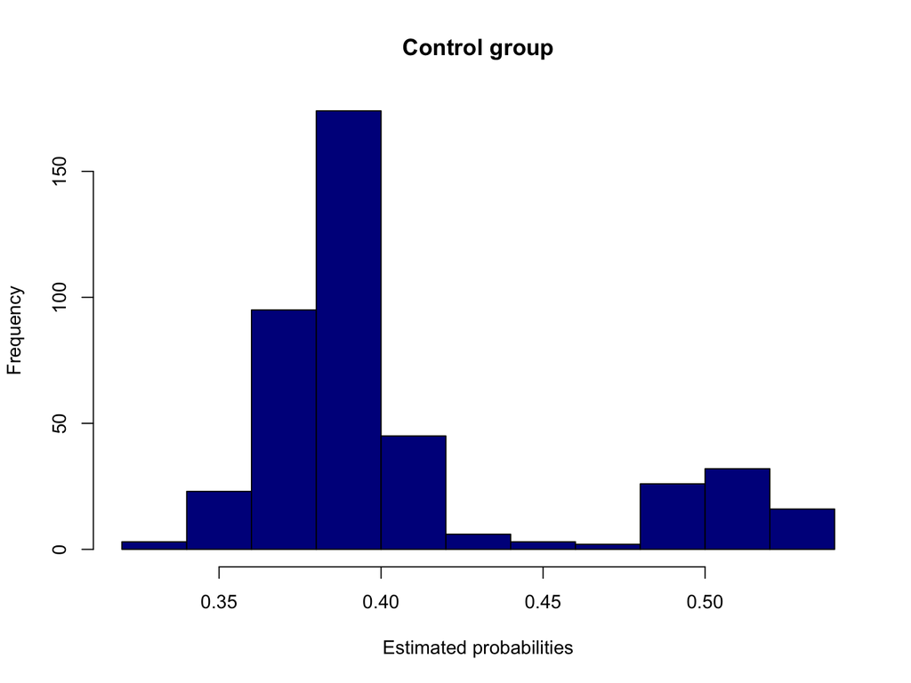

Figure 6. Histogram that shows the distribution of the control group’s estimated probabilities of being predicted as part of the treatment group. The probabilities are estimated by a logistic regression model using every parameter as predictor exlcuding re78 and no interaction terms